Bennett Widyolar  
ES 207 - HW #5  
3/23/2016

# Homework Assignment 5

## Objective

In this study I use my previous studies on the relationship between plant height versus breast height diameter to estimate above-ground carbon stocks in riparian areas.

## Methods

I will be using R as the programming language to analylze the data, develop linear models, and select the most appropriate model. I will look at the effects of additional factors: latitude, elevation, temperature, and precipitation, to see if these improve the models.

## Data

The data for this study came from the ES 207 HW2 folder. Species name, woody stem diameter and height were collected along with longitude and latitude data. This data is ultimately to be used to estimate carbon density at each site.

Raster data showing elevation in California as well as temperature and precipitation values for August of some year are used.

## Code

The code for this project is as follows:

```r
#CLEAR VARIABLES
rm(list=ls())

#install.packages("rgdal")
library(rgdal)
#install.packages("raster")
library(raster)

#LOAD DATA
rip <- read.csv("riparian_cleaned.csv")

#SORT OUT ONLY TOP 5 SPECIES
top5 <- rip[c(which(rip$Genus == "Acer")),]
top5 <- rbind(top5,rip[c(which(rip$Genus == "Quercus")),])
top5 <- rbind(top5,rip[c(which(rip$Genus == "Populus")),])
top5 <- rbind(top5,rip[c(which(rip$Genus == "Salix")),])
top5 <- rbind(top5,rip[c(which(rip$Genus == "Fraxinus")),])
top5 <- droplevels(top5)
rip <- top5
rm(top5)

#ADD HEIGHT AS CM
rip$htcm <- rip$Woody_Height_m * 100  #CONVERT TO CM
#CLEAN DATA OF NULL VALUES
rip <- rip[-c(which(rip$htcm > 6000)), ]

#PLOT DEM RASTER DATA
filename = "DEM.tif"
gdal_grid = readGDAL(filename)
DEM = raster(gdal_grid) #use data as a projected raster
plot(DEM)
#OVERLAY PROJECT LOCATIONS
ProjLoc <- aggregate(cbind(Latitude,Longitude) ~ ProjCode, data=rip, mean)
codeColors = c("red","blue","green","black")
symbols = c(17,19,15,18)
points(ProjLoc$Longitude,ProjLoc$Latitude,col=codeColors,pch=symbols)
legend("topright",inset=0.05,title="Project Site",levels(ProjLoc$ProjCode),pch=symbols,col=codeColors)

#EXTRACT ELEVATION RASTER DATA
rip$Elevation <- extract(DEM,cbind(rip$Longitude,rip$Latitude))
#EXTRACT TEMPERATURE RASTER DATA
filename = "tmean_8.tif"
gdal_grid = readGDAL(filename)
temperature = raster(gdal_grid) #use data as a projected raster
rip$Temp_aug <- extract(temperature,cbind(rip$Longitude,rip$Latitude))
#EXTRACT PRECIPITATION RASTER DATA
#EXTRACT TEMPERATURE RASTER DATA
filename = "precip_8.tif"
gdal_grid = readGDAL(filename)
precipitation = raster(gdal_grid) #use data as a projected raster
rip$Precp_aug <- extract(precipitation,cbind(rip$Longitude,rip$Latitude))

#CLEAN DATA
rip <- rip[-c(which(rip$Elevation > 200)), ]

#TEST DISTRIBUTIONS
#hist(rip$Elevation)
#hist(rip$Precp_aug)
#hist(rip$Temp_aug)
#TEMPERATURE IS SOMEWHAT NORMALLY DISTRIBUTED
#OTHERS ARE NOT

#TEST CORRELATIONS
#cor(rip$Elevation, rip$Precp_aug) - 0.9661259
#cor(rip$Elevation, rip$Temp_aug) - 0.5831392
#cor(rip$Precp_aug, rip$Temp_aug) - 0.6183203
#ELEVATION AND PRECIPITATION IS HIGHLY CORRELATED
#OTHERS NOT SO MUCH

#LINEAR MODELS
lm.pred <- lm(htcm~Woody_DBH_cm*Genus, data=rip) #BASE PREDICTION
lm.pred1 <- lm(htcm~Woody_DBH_cm*Genus + Latitude, data=rip) #WITH LATITUDE
lm.pred2 <- lm(htcm~Woody_DBH_cm*Genus + Elevation, data=rip) #WITH ELEVATION
lm.pred3 <- lm(htcm~Woody_DBH_cm*Genus + Precp_aug, data=rip) #WITH PRECIPITATION
lm.pred4 <- lm(htcm~Woody_DBH_cm*Genus + Temp_aug, data=rip) #WITH TEMPERATURE

AIC(lm.pred,lm.pred1,lm.pred2,lm.pred3,lm.pred4)
#BASED ON THE LINEAR MODELS r SQUARED AND THE AIC VALUE, THE MODEL WITH ELEVATION IS THE BEST, BUT NOT BY MUCH

#temp = subset(rip, Genus == "Quercus")
#temp2 <- lm(temp$htcm ~ temp$Woody_DBH_cm)
#plot(rip$Woody_DBH_cm,rip$htcm)
#abline(coefficients(temp2))

#USING MODEL WITH NEW DATA, USING BASE MODEL SO WE DONT NEED TO ADD ELEVATION DATA TO THE NEW DATA
newData <- read.csv("new_data.csv")
newData$htcm <- predict(lm.pred,newData)
newData$Biomass = 705 * (0.0000334750*(newData$Woody_DBH_cm^2.33631)*(newData$htcm^0.74872))
newData$Carbon = newData$Biomass/2

#Mg of carbon per hectare
print(sum(newData$Carbon/1000*100))
#THIS WILL PROBABLY UNDERESTIMATE - THE  LINEAR MODEL FOR ALL TOP 5 SPECIES HAS A HIGHER INTERCEPT (HEIGHT) THAN THE LINEAR MODEL FOR QUERCUS ALONE.
```

## Results

[output not shown]

```
## DEM.tif has GDAL driver GTiff
## and has 1137 rows and 1233 columns
```

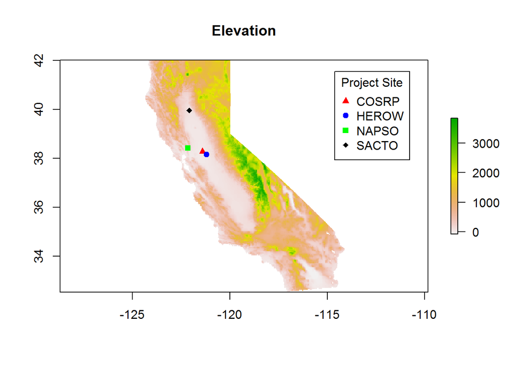

```
## tmean_8.tif has GDAL driver GTiff
## and has 1137 rows and 1233 columns
```

```
## precip_8.tif has GDAL driver GTiff
## and has 862 rows and 744 columns
```

The temperature raster data is somewhat normally distributed, but the precipitation data is not. Elevation and precipitation data is highly correlated.

The following linear models are generated: Base Model: height ~ DBH*Genus Latitude Model: height ~ DBH*Genus + Latitude Elevation Model: height ~ DBH*Genus + Elevation Precipitation Model: height ~ DBH*Genus + Precipitation Temperature Model: height ~ DBH*Genus + Temperature

The R-squared values for each model are listed below.

BASE: 0.6269 Latitude: 0.6268 Elevation: 0.6289 Precipitation: 0.627 Temperature: 0.6268

The AIC values for all linear models (in the order listed above) are listed below.

```
##          df      AIC
## lm.pred  11 46889.81
## lm.pred1 12 46891.73
## lm.pred2 12 46873.92
## lm.pred3 12 46889.93
## lm.pred4 12 46891.73
```

Since the models are all relatively the same and there is no significant improvement in predictive quality by adding extra terms, I use the base model for height predictions.

Using this model, I predict the heights of trees and use the heights to estimate the above ground carbon stocks of trees at a new site (samples from 10m x 10m plot). Assuming 50% tree volume is carbon and based on the density of carbon and extrapolating this 10m x 10m plot to a hectare, I calculate 74,230 Mg of above ground carbon per hectare at the new site.

```
## [1] 74230.21
```

## Discussion

This calculation probably underestimates the total carbon stocks. To predict within a certain confidence interval, I can use the “level” key in the predict function.

## Limitations

The above ground tree-volume equation I am using is for valley oaks. I am extrapolating this equation to all riparian trees counted. Assumption of 50% above ground volume is carbon.